# P8106 Midterm Project Report

Xiaoluo Jiao

3/26/2022

# Introduction

Recently, wine is increasingly enjoyed by a large range of consumers. For wine industry, the quality assessment of wine is a key element for wine making process since it can be used to improve wine making and help to set prices. Thus, identifying the most influential physicochemical factors for the wine quality is important.

## Dataset

In this project, we are interested in which physiochemical properties are critical in allowing a wine to have higher quality and building a model to predict the quality of wine based on those physiochemical features. Our dataset is related to the red variant of the Portuguese “Vinho Verde” wine from the north of Portugal. It is built with 1599 red wine examples, and 11 physicochemical statistics are included. The features are: * fixed_acidity * volatile_acidity * citric_acid * residual_sugar * chlorides * free_sulfur_dioxide * total_sulfur_dioxide * density * p_h * sulphates * alcohol * quality: based on sensory data, score between 0 and 10

## Data Preparation

For the outcome variable `quality`, I set a cutoff making a 7 or higher quality score gets classified as “good” and the remainder as “not good”, because I am interested in a classification model for selecting “high quality wine” in this project. Then I convert `quality` into a factor variable with binary responses. There is no missing data.

After the data cleaning, I split the dataset into two parts: 70% of it goes into the training data, and 30% goes into the test data. The training data contains 1120 observations and the test data contains 479 observations.

# Exploratory analysis

The dataset has 1599 observations and 12 variables. The outcome variable is `quality`, and the predictors are `fixed_acidity`, `volatile_acidity`, `citric_acid`, `residual_sugar`, `chlorides`, `free_sulfur_dioxide`, `total_sulfur_dioxide`, `density`, `p_h`, `sulphates`, `alcohol`. Among these variables, only `quality` is categorical, and the others are continuous.

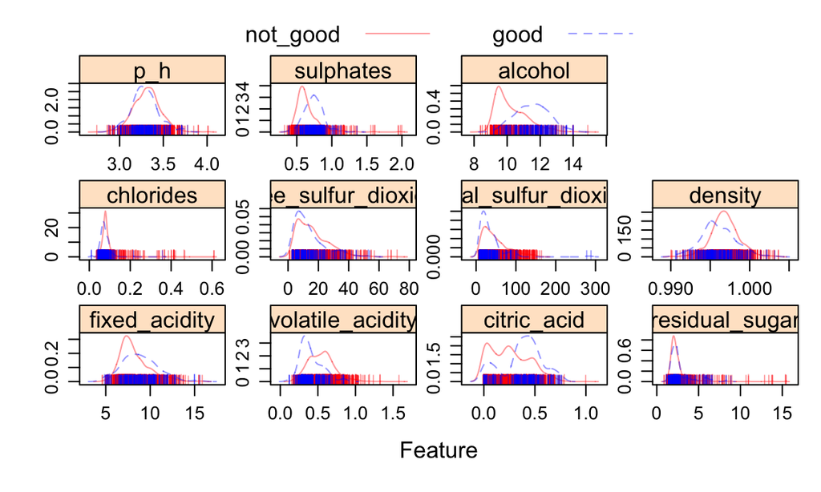

**Figure.1**

According to the Figure.1, we can see that a better quality score might be associated with higher amount of sulphates, higher percent alcohol content, lower volatile acidity, and higher amount of citric acid.

# Models

I keep all 11 variables in the original dataset as predictors. Since we want to predict a binary categorical response, I choose `logistics regression`, `penalized logistics regression`, `GAM`, `MARS`, and `LDA` models to train the data for classification with 5-fold cross validation. Logistic regression model assumes independent observations, linear relationship between predictors and the logit of the response variable, no multicollinearity, and no extreme outliers. GAM and MARS models do not make assumptions. LDA model assumes equal variance.

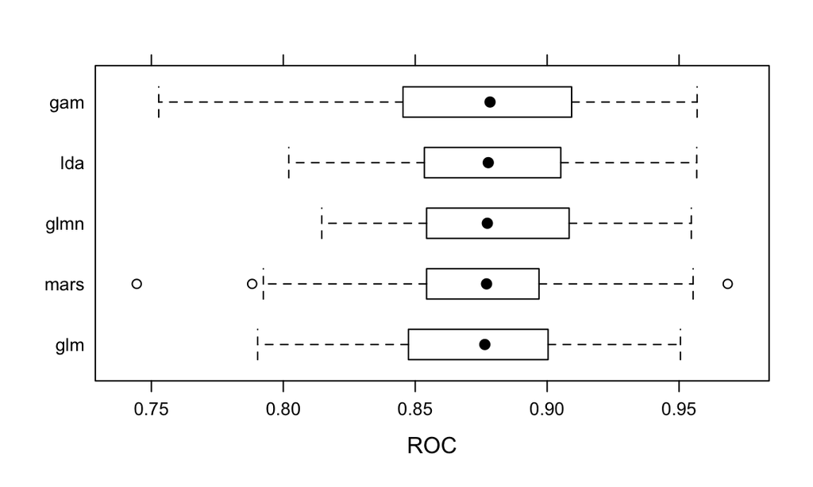

**Figure.2**

According to Figure.2, we can see that by resampling our training data, among the five models, GAM model has the highest ROC value, indicating a better training performance.

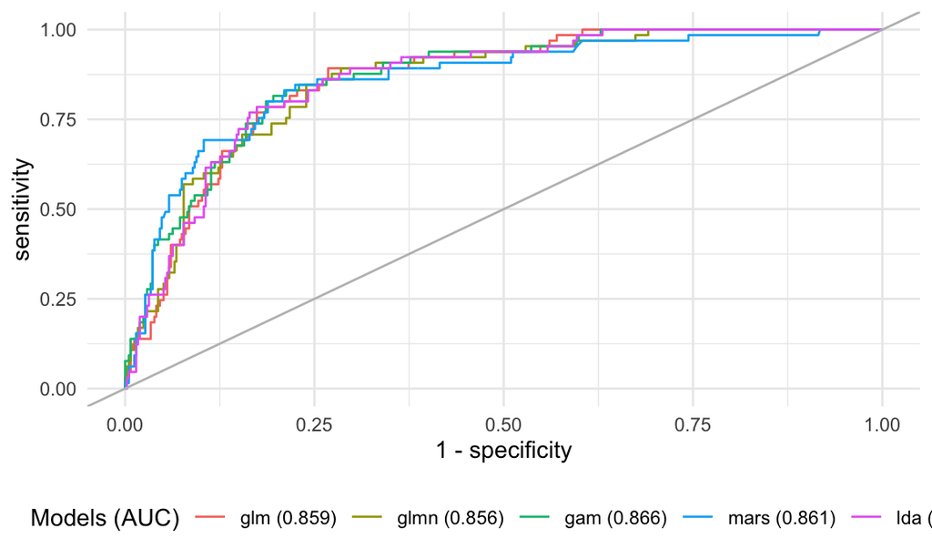

**Figure.3**

Using the test data, a new ROC curves and the corresponding AUC is shown in Figure.3. We can also see that the GAM model has a smoother ROC curve which is closer to the upper left corner of the graph, and it has the highest AUC value (0.866), which indicates that it has the best testing performance. Since the GAM model has the highest ROC and AUC values for both training and test data, I would choose GAM model to predict the quality level of the wine.

```
##
## Family: binomial
## Link function: logit
##
## Formula:
## .outcome ~ s(free_sulfur_dioxide) + s(alcohol) + s(citric_acid) +
##     s(residual_sugar) + s(p_h) + s(sulphates) + s(fixed_acidity) +
##     s(volatile_acidity) + s(chlorides) + s(total_sulfur_dioxide) +
##     s(density)
##
## Parametric coefficients:
##             Estimate Std. Error z value Pr(>|z|)
## (Intercept)  -3.7319     0.3093  -12.06   <2e-16 ***
## ---
## Signif. codes:  0 '***' 0.001 '**' 0.01 '*' 0.05 '.' 0.1 ' ' 1
##
## Approximate significance of smooth terms:
##                               edf Ref.df Chi.sq  p-value
## s(free_sulfur_dioxide)  6.4335779      9 14.465 0.021496 *
## s(alcohol)              3.2210010      9 22.904 8.41e-06 ***
## s(citric_acid)          0.0001055      9  0.000 0.451944
## s(residual_sugar)       1.5401289      9 10.838 0.000502 ***
## s(p_h)                  0.0002599      9  0.000 0.495857
## s(sulphates)            3.7200814      9 59.727  < 2e-16 ***
## s(fixed_acidity)        0.7150668      9  2.048 0.083867 .
## s(volatile_acidity)     7.2262984      9 39.890  < 2e-16 ***
## s(chlorides)            0.7347628      9  1.757 0.106127
## s(total_sulfur_dioxide) 6.3594847      9 17.267 0.006758 **
## s(density)              2.2006929      9  7.586 0.007033 **
## ---
## Signif. codes:  0 '***' 0.001 '**' 0.01 '*' 0.05 '.' 0.1 ' ' 1
##
## R-sq.(adj) =  0.419   Deviance explained = 45.4%
## UBRE = -0.50739  Scale est. = 1         n = 1120
```

One disadvantage of GAM is that the model is less interpretable. In a GAM model, each predictor has converted into a smooth covariate which has nonlinear function, which complicates the interpretation of each parameter.

# Conclusions

In conclusion, GAM model is the best model to predict the quality level of wine. Similar as we expected in the exploratory part, `alcohol`, `sulphates`, `volatile_acidity`, `total_sulfur_dioxide`, and `density` are statistically significant predictors for predicting the quality level; besides, `free_sulfur_dioxide` and `residual_sugar` are also important variables. The model provide a good reference for the wine industry on the quality assessment of wine during the wine making process.